# Data Handling

Importing and Tidying

Week 3

# 1 Packages to load…

These packages are required to be able to handle data effectively in R studio:

- tidyverse
- vroom
- devtools

These can be installed via: `install.packages("package name", dependencies = TRUE)`

They are run via: `library(package name)`

# 2 Loading information into R studio

The data required must be read in to R using

`vroom("location of data on desktop/location of data in github)` * Prefered location is public github as this makes it accessible for everyone

And then saved as a named vector, as shown below for the workshop three data:

```r
pop_1_dat <- vroom("to_sort_pop_1.csv")
pop_2_dat <- vroom("to_sort_pop_2.csv")
```

**If the data is found in the repository folder you are working in the full pathway from the desktop is not needed**

# 3 Joining data frames together

Use the `join()` function to combine data sets together. Depending on what parts of the data you want to join.

```r
combined_pop_data <- full_join(pop_1_dat, pop_2_dat, by = NULL, match = "all")
```

- `by` = if NULL will match all common variables

# 4 Converting *wide* data to *long* form data

This data is wide and so must be converted to long form data for ease of processing.

Use the `pivot_longer()` function and enter the column headings required:

```r
long_pop_data <- combined_pop_data %>%
  pivot_longer(cols = -c( species,
                          primary_threat,
                          secondary_threat,
                          tertiary_threat))
```

- To identify the names of the columns either visualise the combined data or click the vector name in the global environment to produce a pop-out table:

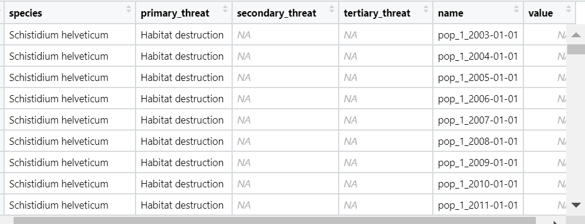

  Figure 1. Pop-out table of combined population data

# 5 Changing column headings

To edit column headings use the `name()` function, stating the location of the headings to be changed in `[]` and then creating a list of the new names:

```r
names(covid_dat)[1:2] <- c("Province.State", "Country.Region")
```

# 6 Renaming observation columns

As seen is figure 1 there are two columns with R assigned headings ‘name’ and ‘value’. To change these to customised headings we use the pivot_longer function again, keeping the variables we want to remain the same in a vector, and substitute our desired names:

```r
long_pop_data <- combined_pop_data %>%
  pivot_longer(cols = -c( species:tertiary_threat),
               names_to = "date",
               values_to = "abundance")
```

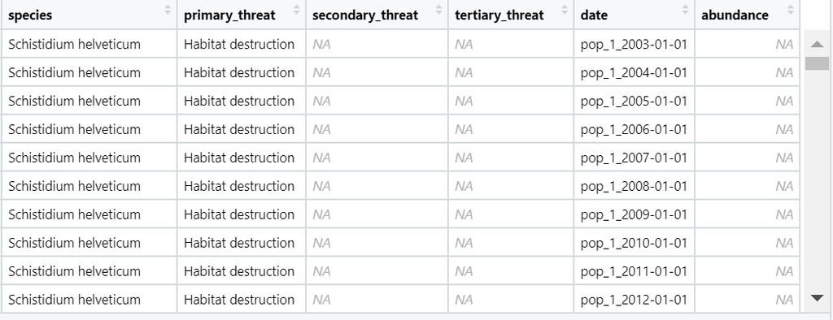

Figure 2. Pop-out table of renamed columns

# 7 Splitting one column into two

As seen in figure 2 the population group is joined together with the date therefore these must be separated into a separate ‘population’ column and ‘date’ column.

The `tidyr` package must be loaded to be able to use the `separate` function to do this and is used as below: `separate(original_column,` `c("new_heading_1", "new_heading_2"), sep = number of spaces in value before columns separated)`

In practise:

```r
library("tidyr")
finished_data <- long_pop_data %>%
  separate(date,
           c("population", "date"), sep = 6)
```

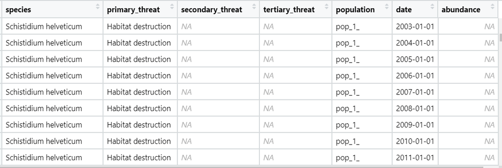

Figure 3. Pop-out table of tidied data set

# 8 Condenscing actions into one block of code

Using tidyverse functions:

```r
long_spp <- combined_pop_data %>%
  pivot_longer(cols = -c( species,
                          primary_threat,
                          secondary_threat,
                          tertiary_threat),
               names_to = c("population", "date"),
               names_pattern = "(.*)_(.*)",
               values_drop_na = F,
               values_to = "abundance")
long_spp
```